# Thesis Data Analysis

Islamov Ayrat

2024-06-17

# Анализ данных эксперимента выпускной бакалаврской работы

## Вводные данные

Здесь представлен код, написанный мной для анализа данных полученных в ходе когнитивного психолгического эксперимента. Данный эксперимент был проведен нами в рамках выпускной квалификационной работы (ВКР), направленной на изучение восприятия интерфейсов. Подробнее о теме ВКР и её эксперментальном плане вы можете узнать из презентации, представленной на репозитории. Здесь я постараюсь описать лишь те части работы, которые необходимы для понимания логики анализа данных.

Датасет представляет из себя данные проб эксперимента 99 участников, где каждая строка представляет из себя единичную пробу. В колонках представлены различные экспериментальные данные. Рассмотрим интресеующие нас колонки-переменные.

**N.B.** Представленнные данные предвавриательно очищены от выбросов (2 стандартных отклонения) по времени реакции (относительно ответов каждого испытуемого). Также данные очищены от некорректных ответов. Данные шаги не включены в анализ, так как затрагивают конфиденциальную информацию испытуемых. Далее мы будем работать с данными, не затрагивающимии конфиденциальную информацию.

```r
df = read.csv('exp_data.csv')
summary(df)
```

```
##        X              ID            Sex                 Age
##  Min.   :   1   Min.   : 1.00   Length:7945        Min.   :18.00
##  1st Qu.:1987   1st Qu.:25.00   Class :character   1st Qu.:20.00
##  Median :3973   Median :50.00   Mode  :character   Median :21.00
##  Mean   :3973   Mean   :49.82                      Mean   :20.87
##  3rd Qu.:5959   3rd Qu.:75.00                      3rd Qu.:22.00
##  Max.   :7945   Max.   :99.00                      Max.   :27.00
##
##  group_sk_fl_neu        date             expName          psychopyVersion
##  Length:7945        Length:7945        Length:7945        Length:7945
##  Class :character   Class :character   Class :character   Class :character
##  Mode  :character   Mode  :character   Mode  :character   Mode  :character
##
##
##
##
##       OS              frameRate       test_chose_targ.x test_chose_targ.y
##  Length:7945        Min.   :  6.676   Mode:logical      Mode:logical
##  Class :character   1st Qu.: 59.172   NA's:7945         NA's:7945
##  Mode  :character   Median : 59.880
##                     Mean   : 64.373
##                     3rd Qu.: 60.241
##                     Max.   :250.000
##
##  test_chose_targ.leftButton test_chose_targ.midButton
##  Mode:logical               Mode:logical
##  NA's:7945                  NA's:7945
##
##
##
##
##
##  test_chose_targ.rightButton test_chose_targ.time test_chose_targ.corr
##  Mode:logical                Mode:logical         Mode:logical
##  NA's:7945                   NA's:7945            NA's:7945
##
##
##
##
##
```

[output cut: 57 more lines]

```
##  Min.   :0            Min.   : 0.00   Min.   :0           Min.   :1
##  1st Qu.:0            1st Qu.:23.00   1st Qu.:0           1st Qu.:1
##  Median :0            Median :46.00   Median :0           Median :1
##  Mean   :0            Mean   :45.26   Mean   :0           Mean   :1
##  3rd Qu.:0            3rd Qu.:68.00   3rd Qu.:0           3rd Qu.:1
##  Max.   :0            Max.   :89.00   Max.   :0           Max.   :1
##  NA's   :80
##  test_loop.thisTriAL2N main_loop.thisTriAL2N
##  Mode:logical          Min.   :0
##  NA's:7945             1st Qu.:0
##                        Median :0
##                        Mean   :0
##                        3rd Qu.:0
##                        Max.   :0
##                        NA's   :7865
```

ID - индивидуальный номер участника

Sex - пол (2 уровня: m/f)

Age - возраст group_sk_fl_neu - экспеиментальная группа участника, соответвующая типу дизайна, в котором он проходил тестирование. 3 уровня: sk - скевоморфный дизайн neu - неоморфический дизайн fl- плоский дизайн

stim_name - имя целевого стимула, который искал на экране испытуемый

stim_fav - категория знакомости стимула (2 уровня: 0 - незнакомый, 1 - знакомый)

matrix_type - размер интерфейса, в котором инспытуемый осуществлял поиск (3 уровня: 1 - сетка 3х3 2 - сетка 4х4 3 - сетка 5х5)

chose_targ.time - время ответа испытуемого, в секундах

## Подготовка данных

Для начала приведем необходимые переменные к корректному типу

```r
df$group_sk_fl_neu =as.factor(df$group_sk_fl_neu)
df$stim_fav = as.factor(df$stim_fav)
df$matrix_type=as.factor(df$matrix_type)
df$ID =as.factor(df$ID)
df$Sex =as.factor(df$Sex)
str(df$Sex)
```

```
##  Factor w/ 7 levels "f","FALSE","m",..: 1 1 1 1 1 1 1 1 1 1 ...
```

Заметим, что пол заявлен как двухуровневая факторная переменная, однако по данным таковой не является. Исправим это.

```r
df$Sex = tolower(df$Sex)
df$Sex = ifelse(df$Sex=='ж' | df$Sex=='false', 'f', df$Sex)
df$Sex = ifelse(df$Sex=='м', 'm', df$Sex)
df$Sex =as.factor(df$Sex)
str(df$Sex)
```

```
##  Factor w/ 2 levels "f","m": 1 1 1 1 1 1 1 1 1 1 ...
```

## Обзор данных

Выведем статистики, характеризующие нашу выборку (пол и возраст).

```r
df[, 2:4] %>%
  unique() %>%
  select(2,3) %>%
  summary()
```

```
##  Sex         Age
##  f:63   Min.   :18.00
##  m:36   1st Qu.:20.00
##         Median :21.00
##         Mean   :20.88
##         3rd Qu.:22.00
##         Max.   :27.00
```

Выведем статистику времени поиска каждого из стимулов. Возможно есть смысл удалить часть из них.

```r
df %>%
  group_by(group_sk_fl_neu, stim_name) %>%
  summarise(time = mean(chose_targ.time)) %>%
  arrange(time)
```

```
## # A tibble: 100 × 3
## # Groups:   group_sk_fl_neu [3]
##    group_sk_fl_neu stim_name    time
##    <fct>           <chr>       <dbl>
##  1 fl              cAL2endar    1.09
##  2 neu             ruler        1.31
##  3 fl              cAL2culator  1.38
##  4 sk              ruler        1.39
##  5 fl              gAL2lery     1.48
##  6 sk              calculator   1.60
##  7 sk              camera       1.65
##  8 sk              settings     1.69
##  9 fl              ruler        1.70
## 10 neu             settings     1.70
## # ℹ 90 more rows
```

```r
df %>%
  group_by(group_sk_fl_neu, stim_name) %>%
  summarise(time = mean(chose_targ.time)) %>% ungroup() %>%  shapiro_test(time)
```

```
## # A tibble: 1 × 3
##   variable statistic     p
##   <chr>        <dbl> <dbl>
## 1 time         0.990 0.664
```

Все стимулы искались в допустимых интервалах от 1.09 до 3.66 секунд. Распредление нормальное. Оснований для удаления проб с конкретными стимулами обнаружено не было.

## Агрегация данных и основные описательные статистики

Согласно экспериментальному плану агрегируем данные о времени реакции по испытуемым и ро каждому из экспериментальных условий: дизайн стимулов, знакомоость стимулов, количество стимулов.

```r
merged_data = df %>%
  group_by(ID, group_sk_fl_neu, matrix_type, stim_fav) %>%
  summarise(
    time = mean(chose_targ.time)
    ) %>%
  ungroup()
```

```
## can override using the `.groups` argument.
```

Взглянем на основные описательные статистики:

```r
merged_data %>%
  group_by(group_sk_fl_neu, matrix_type, stim_fav
           ) %>%
  get_summary_stats(time, type = "mean_sd")
```

```
## # A tibble: 18 × 7
##    group_sk_fl_neu matrix_type stim_fav variable     n  mean    sd
##    <fct>           <fct>       <fct>    <fct>    <dbl> <dbl> <dbl>
##  1 fl              1           0        time        32  2.12 0.527
##  2 fl              1           1        time        32  1.84 0.417
##  3 fl              2           0        time        32  2.63 0.6
##  4 fl              2           1        time        32  2.46 0.542
##  5 fl              3           0        time        32  3.05 0.913
##  6 fl              3           1        time        32  3.02 0.856
##  7 neu             1           0        time        31  1.84 0.485
##  8 neu             1           1        time        31  1.71 0.359
##  9 neu             2           0        time        31  2.25 0.603
## 10 neu             2           1        time        31  2.35 0.586
## 11 neu             3           0        time        31  2.88 0.767
## 12 neu             3           1        time        31  2.83 0.719
## 13 sk              1           0        time        36  2.05 0.465
## 14 sk              1           1        time        36  1.91 0.402
## 15 sk              2           0        time        36  2.56 0.596
## 16 sk              2           1        time        36  2.53 0.665
## 17 sk              3           0        time        36  2.91 0.901
## 18 sk              3           1        time        36  2.91 0.9
```

Добавим предварительную визуализацию:

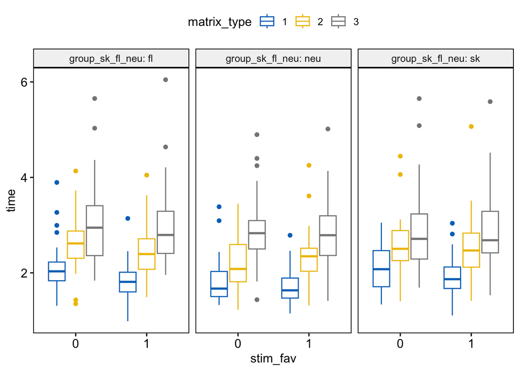

```r
bxp1 <- ggboxplot(
  merged_data,
  y = "time",
  x = "stim_fav",
  color = "matrix_type",
  facet.by = "group_sk_fl_neu",
  palette = "jco",
  short.panel.labs = FALSE
)
bxp1
```

## Подготовка к проведению дисперсионного анализа, проверка условий.

Для анализа данных мы планируем проводить трехфакторный смешанный дисперсионнный анализ для выявления влияния каждого из факторов и влияния их взаимодействия.

Выведем список выбросов

```r
merged_data %>%
  group_by(matrix_type, group_sk_fl_neu, stim_fav) %>%
  identify_outliers(time)
```

```
## # A tibble: 31 × 7
##    group_sk_fl_neu matrix_type stim_fav ID     time is.outlier is.extreme
##    <fct>           <fct>       <fct>    <fct> <dbl> <lgl>      <lgl>
##  1 fl              1           0        7      2.99 TRUE       FALSE
##  2 fl              1           0        14     2.85 TRUE       FALSE
##  3 fl              1           0        32     3.89 TRUE       TRUE
##  4 fl              1           0        56     3.27 TRUE       FALSE
##  5 fl              1           1        32     3.14 TRUE       FALSE
##  6 neu             1           0        17     3.38 TRUE       FALSE
##  7 neu             1           0        50     3.09 TRUE       FALSE
##  8 neu             1           1        43     2.79 TRUE       FALSE
##  9 sk              1           1        21     2.81 TRUE       FALSE
## 10 sk              1           1        77     3.04 TRUE       FALSE
## # ℹ 21 more rows
```

Как мы видим, всего 5 строчек попадают под критерий экстремальных выбросов (> 3 отклонений). Будем иметь это в виду и при необходимости удалим.

Рассмотрим нормальность распредления целевой переменной в каждой из ячеек дизайна

```r
merged_data %>%
  group_by(matrix_type, stim_fav, group_sk_fl_neu) %>%
  shapiro_test(time)
```

```
## # A tibble: 18 × 6
##    group_sk_fl_neu matrix_type stim_fav variable statistic        p
##    <fct>           <fct>       <fct>    <chr>        <dbl>    <dbl>
##  1 fl              1           0        time         0.869 0.00108
##  2 neu             1           0        time         0.820 0.000125
##  3 sk              1           0        time         0.962 0.250
##  4 fl              1           1        time         0.959 0.251
##  5 neu             1           1        time         0.929 0.0411
##  6 sk              1           1        time         0.959 0.194
##  7 fl              2           0        time         0.969 0.466
##  8 neu             2           0        time         0.929 0.0419
##  9 sk              2           0        time         0.926 0.0192
## 10 fl              2           1        time         0.943 0.0937
## 11 neu             2           1        time         0.916 0.0181
## 12 sk              2           1        time         0.891 0.00196
## 13 fl              3           0        time         0.927 0.0316
## 14 neu             3           0        time         0.956 0.235
## 15 sk              3           0        time         0.911 0.00711
## 16 fl              3           1        time         0.862 0.000751
## 17 neu             3           1        time         0.955 0.215
## 18 sk              3           1        time         0.947 0.0854
```

Построим график распределения квантилей в качестве альтернативы оценки характера распредления данных.

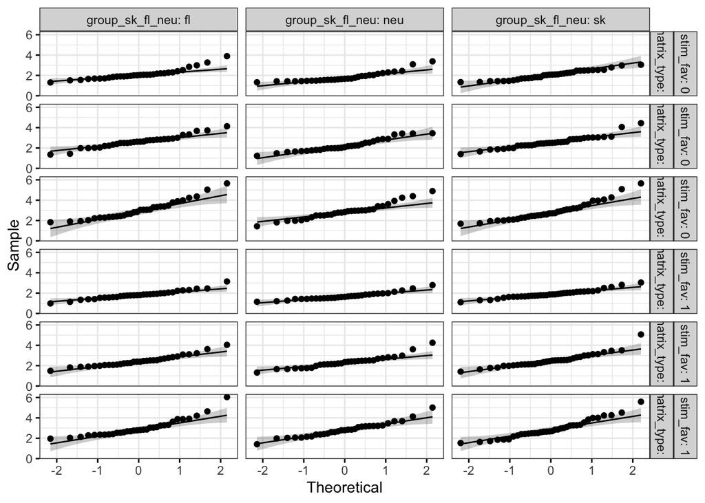

```r
ggqqplot(merged_data, "time", ggtheme = theme_bw()) +
  facet_grid(stim_fav + matrix_type ~ group_sk_fl_neu, labeller = "label_both")
```

Согласно графику можно говорить, что большинство наблюдений входят в доверительный интервал распредления квантилей. Лишь небольшая часть данных выходит за пределы доверительного интервала. Учитывая это и устойчивость смешанного дисперсионного анализа к выбросам и ненормальности данных, считаем проведение дисперсионного анализа допустимым.

Наконец, проведем проверку равенства дисперсий у различных групп экспериментального дизайна.

```r
merged_data %>%
  group_by(matrix_type, stim_fav) %>%
  levene_test(time ~ group_sk_fl_neu)
```

```
## # A tibble: 6 × 6
##   matrix_type stim_fav   df1   df2 statistic     p
##   <fct>       <fct>    <int> <int>     <dbl> <dbl>
## 1 1           0            2    96     0.150 0.861
## 2 1           1            2    96     0.131 0.877
## 3 2           0            2    96     0.122 0.885
## 4 2           1            2    96     0.219 0.804
## 5 3           0            2    96     0.526 0.593
## 6 3           1            2    96     0.476 0.622
```

Условие равнества дисперсий не нарушено. Можно переходить к проваедению основного анализа.

## Дисперсионный смешаннный анализ. Three-WAY MIXED ANOVA

Обаратим внимание на факторный дизайн: факторы размера интерфейса и знакомости иконки (matrix_type, stim_fav) варьировались для каждого участника (внутригрупповой фактор), в то время как фактор дизайна варьировался между испытуемыми (каждый испытунмый проходил эксперимент только в одном из видов дизайна).

```r
res.aov <- anova_test(
  data = merged_data, dv = time, wid = ID,
  between = group_sk_fl_neu, within = c(matrix_type, stim_fav)
)
get_anova_table(res.aov)
```

```
## ANOVA Table (type III tests)
##
##                                 Effect  DFn    DFd       F        p p<.05   ges
## 1                      group_sk_fl_neu 2.00  96.00   1.308 2.75e-01       0.019
## 2                          matrix_type 1.62 155.05 252.685 1.49e-44     * 0.295
## 3                             stim_fav 1.00  96.00   7.777 6.00e-03     * 0.004
## 4          group_sk_fl_neu:matrix_type 3.23 155.05   0.907 4.45e-01       0.003
## 5             group_sk_fl_neu:stim_fav 2.00  96.00   1.753 1.79e-01       0.002
## 6                 matrix_type:stim_fav 1.87 179.77   3.166 4.80e-02     * 0.003
## 7 group_sk_fl_neu:matrix_type:stim_fav 3.75 179.77   0.702 5.82e-01       0.001
```

Кратко рассмотрим полученные результаты.

На уровне значимости 0.05 значимыми оказались основные факторы:

-размера интерфейса

-знакомости стимула

Также зеначимым оказалось взаимодействие факторов:

-размера стимула и знакомости стимула

Отметим, что размер эффекта у значимых факторов различный:

-размер интерефейса обладает большим размером эффекта

-знакомость стимула обладает маленьким размером эффекта

-взаимодействие факторов обладает маленьким размером эффекта

## Post-Hoc исследование

Трехфакторное взаимодействие оказалось незначимым. Кроме того, фактор дизайна, а также все взаимодействия, связанные с ним, оказались незначимыми. Есть смысл исключить этот фактор из дальнейшего анализа и провести двухфакторный анализ. Не забудем про поправки для повторных измерений.

```r
res.aov2 <- anova_test(
  data = merged_data, dv = time, wid = ID,
  within = c(stim_fav, matrix_type)) %>%
  adjust_pvalue(method = "bonferroni")
get_anova_table(res.aov2)
```

```
## ANOVA Table (type III tests)
##
##                 Effect  DFn    DFd       F        p p<.05   ges
## 1             stim_fav 1.00  98.00   7.605 7.00e-03     * 0.004
## 2          matrix_type 1.61 157.48 252.146 1.11e-44     * 0.289
## 3 stim_fav:matrix_type 1.87 183.23   3.151 4.80e-02     * 0.003
```

Все исследуемые факторы оказались значимыми. Размеры эффектов остались прежними. Чтобы выяснить влияние взаимодействия факторов проведем попарный тест с поправками.

```r
pair <- merged_data %>%
  group_by(matrix_type) %>%
  pairwise_t_test(time ~ stim_fav,
                  p.adjust.method = "bonferroni",
                  paired = TRUE,
                  detailed = TRUE,
                  var.equal = TRUE)
pair
```

```
## # A tibble: 3 × 16
##   matrix_type estimate .y.   group1 group2    n1    n2 statistic         p    df
## * <fct>          <dbl> <chr> <chr>  <chr>  <int> <int>     <dbl>     <dbl> <dbl>
## 1 1             0.182  time  0      1         99    99     4.81    5.41e-6    98
## 2 2             0.0366 time  0      1         99    99     0.734   4.65e-1    98
## 3 3             0.0274 time  0      1         99    99     0.462   6.45e-1    98
## # ℹ 6 more variables: conf.low <dbl>, conf.high <dbl>, method <chr>,
## #   alternative <chr>, p.adj <dbl>, p.adj.signif <chr>
```

Как видно из резултатов тестов, есть значимые различия в поиске знакомых и незнакомых иконок наблюдаются только в случае с маленькими интерфейсами (matrix_type = 1)

Визуалитзируем полученные результаты:

(а также исправим названия осей и уровней факторов)

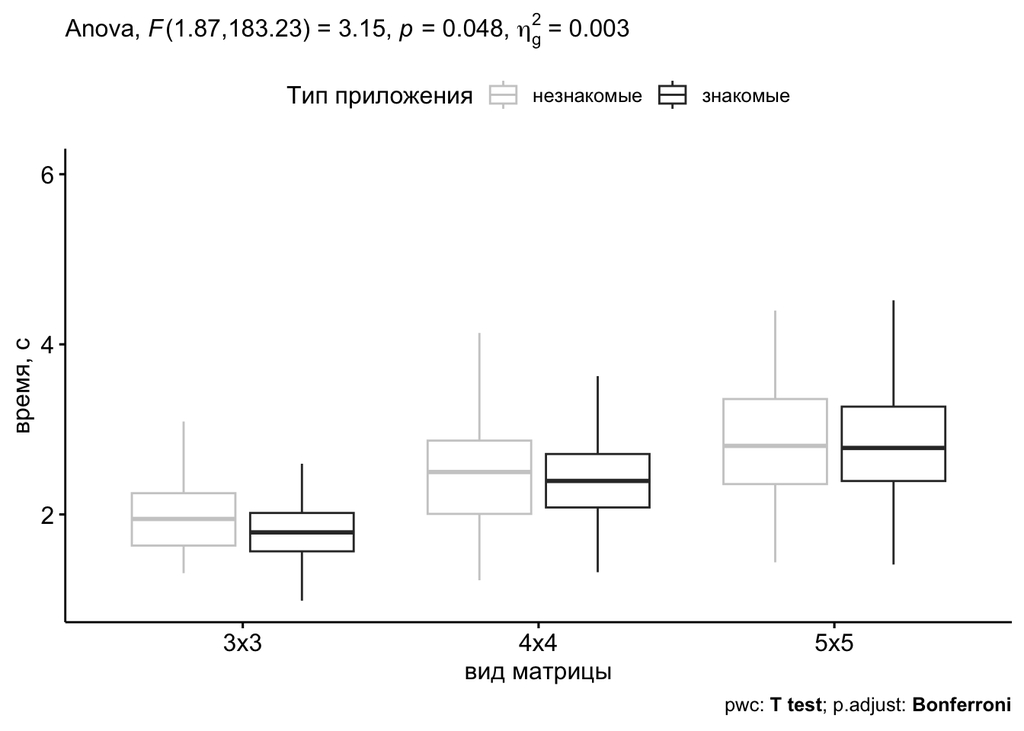

```r
levels(merged_data$matrix_type) <- list('3x3'  = "1", '4x4' = "2", '5x5' = '3' )
levels(merged_data$stim_fav) <- list('незнакомые'  = "0", 'знакомые' = "1")
levels(merged_data$matrix_type) <- list('3x3'  = "1", '4x4' = "2", '5x5' = '3' )
bxp_interaction <- ggboxplot(
  merged_data,
  y = "time",
  x = "matrix_type",
  color = "stim_fav",
  #facet.by = "group_sk_fl_neu",
  palette = "grey",
  short.panel.labs = FALSE,
  xlab = 'вид матрицы',
  ylab = 'время, с',
  #panel.labs = list(stim = c("3х3", "4х4","5х5")),
  outlier.shape = NA
)
bxp_interaction = bxp_interaction  + labs(color = "Тип приложения")

pair <- pair %>% add_xy_position(x = "matrix_type")
pair.filtered <- pair %>% filter(matrix_type == "3x3")
bxp_interaction +
  stat_pvalue_manual(pair.filtered, tip.length = 0, hide.ns = TRUE) +
  labs(
    subtitle = get_test_label(res.aov2, detailed = TRUE),
    caption = get_pwc_label(pair)
  )
```

Помимо этого визуализируем основные факторы модели.

Размер интерфейса, статистики:

```r
pair_matrix <- merged_data %>%
  pairwise_t_test(time ~ matrix_type,
                  p.adjust.method = "bonferroni",
                  paired = TRUE,
                  detailed = TRUE,
                  var.equal = TRUE)
pair_matrix
```

```
## # A tibble: 3 × 15
##   estimate .y.   group1 group2    n1    n2 statistic        p    df conf.low
## *    <dbl> <chr> <chr>  <chr>  <int> <int>     <dbl>    <dbl> <dbl>    <dbl>
## 1   -0.551 time  3x3    4x4      198   198     -17.5 4.51e-42   197   -0.612
## 2   -1.02  time  3x3    5x5      198   198     -22.4 3.61e-56   197   -1.10
## 3   -0.465 time  4x4    5x5      198   198     -10.8 1.42e-21   197   -0.550
## # ℹ 5 more variables: conf.high <dbl>, method <chr>, alternative <chr>,
## #   p.adj <dbl>, p.adj.signif <chr>
```

Очевидно, что с размером интерфейса время поиска увеличивается. Визуализируем этот эффект:

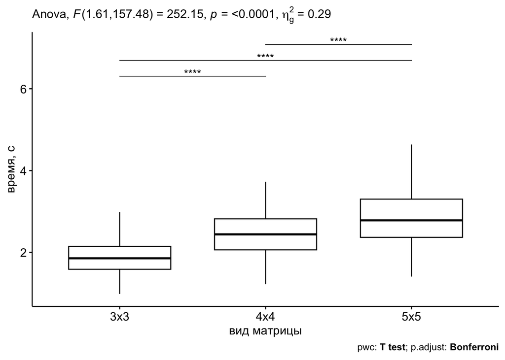

```r
bxp_matrix <- ggboxplot(
  merged_data,
  y = "time",
  x = "matrix_type",
  #color = "stim_fav",
  #facet.by = "group_sk_fl_neu",
  palette = "jco",
  short.panel.labs = FALSE,
  xlab = 'вид матрицы',
  ylab = 'время, с',
  #panel.labs = list(matrix_type = c("3х3", "4х4","5х5")),
  outlier.shape = NA
)
#bxp_matrix = bxp_matrix + ylim(0,6)
pair_matrix <- pair_matrix %>% add_xy_position(x = "matrix_type")

bxp_matrix +
  stat_pvalue_manual(pair_matrix, tip.length = 0, hide.ns = TRUE) +
  labs(
    subtitle = get_test_label(res.aov2, detailed = TRUE, row =2),
    caption = get_pwc_label(pair_matrix)
  )
```

Знакомость приложений, визулизация:

(Так как фактор имеет всего два уровня, дополнительые сравнения и поправки вводить не будем)

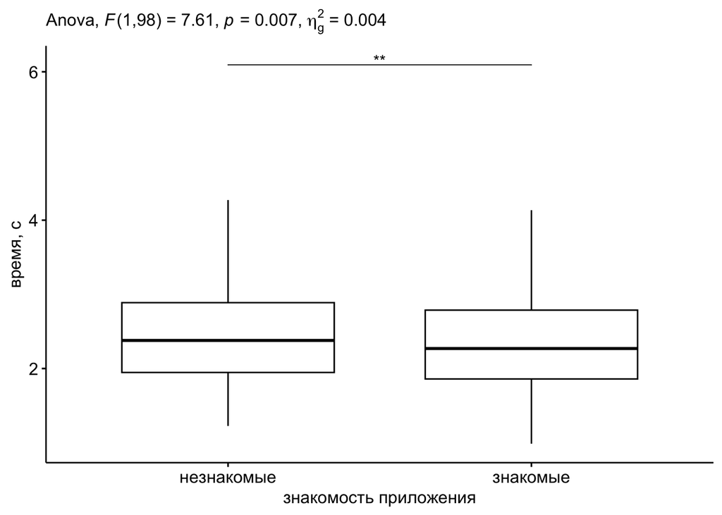

```r
bxp_fav <- ggboxplot(
  merged_data,
  y = "time",
  x = "stim_fav",
  #color = "stim_fav",
  #facet.by = "group_sk_fl_neu",
  palette = "jco",
  short.panel.labs = FALSE,
  xlab = 'знакомость приложения',
  ylab = 'время, с',
  outlier.shape = NA
)


pair_fav <- merged_data %>%
  pairwise_t_test(time ~ stim_fav,
                  p.adjust.method = "none",
                  paired = TRUE,
                  detailed = TRUE,
                  var.equal = TRUE)

pair_fav <- pair_fav %>% add_xy_position(x = "stim_fav")
bxp_fav +
  stat_pvalue_manual(pair_fav, tip.length = 0, hide.ns = TRUE) +
  labs(
    subtitle = get_test_label(res.aov2, detailed = TRUE, row=1)
  )
```

Дополительно для последующей работы в других средах, переведем данные в широкий формат.

```r
wide =dcast(merged_data, ID ~ stim_fav + matrix_type, value.var = 'time')
name_design = merged_data %>% select(group_sk_fl_neu, ID) %>% unique()
wide = left_join(wide, name_design, 'ID')
wide
```

```
##    ID незнакомые_3x3 незнакомые_4x4 незнакомые_5x5 знакомые_3x3 знакомые_4x4
## 1   1       2.032133       2.368067       3.072818    1.7165333     2.863733
## 2   2       2.276136       2.742757       3.056250    1.8846333     2.510693
## 3   3       1.309820       1.432708       2.348450    1.3381533     2.521900
## 4   4       1.516820       2.777413       1.941209    1.6110143     2.224585
## 5   5       1.484027       2.194079       2.831236    1.4257133     2.520373
## 6   6       1.428538       1.965285       2.318989    1.6724083     2.347114
## 7   7       2.994373       2.871221       3.382354    2.0742200     2.636450
## 8   8       2.016900       2.499346       3.082675    1.9985733     2.150933
## 9   9       2.006058       3.005986       2.221092    1.5700786     1.878247
## 10 10       1.565607       1.986992       2.037940    1.5274600     1.749238
## 11 11       1.751936       2.220383       2.733131    1.8594286     2.547318
## 12 12       1.690240       1.973808       3.410227    1.6334333     2.089069
## 13 13       2.266673       2.482579       2.598554    1.6433467     1.985986
## 14 14       2.845943       3.331529       3.048500    1.9810400     3.094860
```

[output cut: 185 more lines]

## Робустные методы

В случае, если соблюдение нормальности и отсутствия выбросов критично для исследования воспользуемся робустными методами анализа.

Частным случаем является ранговая трансформация (ANOVA of Aligned Rank Transformed Data).

```r
library(ARTool)
robust=art(
  time~group_sk_fl_neu*stim_fav*matrix_type+(1|ID),
  merged_data,
  rank.comparison.digits = -floor(log10(.Machine$double.eps^0.5)),
  check.errors.are.factors = TRUE
)
anova(robust)
```

```
## Analysis of Variance of Aligned Rank Transformed Data
##
## Table Type: Analysis of Deviance Table (Type III Wald F tests with Kenward-Roger df)
## Model: Mixed Effects (lmer)
## Response: art(time)
##
##                                                F Df Df.res   Pr(>F)
## 1 group_sk_fl_neu                        1.73342  2     96 0.182162
## 2 stim_fav                               6.11843  1    480 0.013723   *
## 3 matrix_type                          386.36995  2    480  < 2e-16 ***
## 4 group_sk_fl_neu:stim_fav               2.67235  2    480 0.070118   .
## 5 group_sk_fl_neu:matrix_type            2.51917  4    480 0.040545   *
## 6 stim_fav:matrix_type                   1.75398  2    480 0.174192
## 7 group_sk_fl_neu:stim_fav:matrix_type   0.81631  4    480 0.515140
## ---
## Signif. codes:   0 '***' 0.001 '**' 0.01 '*' 0.05 '.' 0.1 ' ' 1
```

В случае с этим методом мы получили похожие резултаты по основным эффектам, однако по взаимодействию факторов результаты отличаются от обычного дисперсионного анализа.

Воспользуемся методом перестановок, а для ускорения процесса распараллелим процесс.

```r
library(doParallel)
library(ez)
library(parallel)

core_n = detectCores()
registerDoParallel(cores=core_n)
library(ez)
ezPerm(
  merged_data
  , time
  , ID
  , within = c(matrix_type, stim_fav)
  , between = group_sk_fl_neu
  , perms = 1e4
  , parallel = TRUE
  , alarm = FALSE
)
```

```
## Progress disabled when using parallel plyr
```

```
##                                 Effect      p p<.05
## 1                      group_sk_fl_neu 0.2720
## 2                          matrix_type 0.0000     *
## 3                             stim_fav 0.4131
## 4          group_sk_fl_neu:matrix_type 0.0010     *
## 5             group_sk_fl_neu:stim_fav 0.1690
## 6                 matrix_type:stim_fav 0.0381     *
## 7 group_sk_fl_neu:matrix_type:stim_fav 0.5080
```

В этом случае мы получили совем другие резултаты: как по основным эффектам, так и по взаимодействию. Фактор дизайна остался незначимым.

Посмотрим на результаты еще одного из методов, а именно степенной странсформации BOX-COX. Подберем коэфицент трансформации:

```r
library(MASS)
```

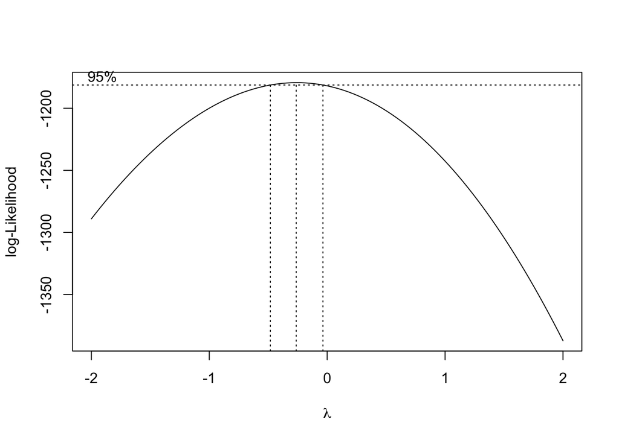

```r
bc <- boxcox(lm(time~1, data = merged_data))
```

```r
lambda <- bc$x[which.max(bc$y)]
merged_data$timetrans <- (merged_data$time^lambda- 1)/lambda
```

Проверим нормальность данных теперь:

```r
merged_data %>%
  group_by(matrix_type, stim_fav, group_sk_fl_neu) %>%
  shapiro_test(timetrans)
```

```
## # A tibble: 18 × 6
##    group_sk_fl_neu matrix_type stim_fav   variable  statistic      p
##    <fct>           <fct>       <fct>      <chr>         <dbl>  <dbl>
##  1 fl              3x3         незнакомые timetrans     0.965 0.380
##  2 neu             3x3         незнакомые timetrans     0.910 0.0128
##  3 sk              3x3         незнакомые timetrans     0.959 0.204
##  4 fl              3x3         знакомые   timetrans     0.966 0.396
##  5 neu             3x3         знакомые   timetrans     0.982 0.858
##  6 sk              3x3         знакомые   timetrans     0.978 0.681
##  7 fl              4x4         незнакомые timetrans     0.931 0.0422
##  8 neu             4x4         незнакомые timetrans     0.972 0.564
##  9 sk              4x4         незнакомые timetrans     0.967 0.361
## 10 fl              4x4         знакомые   timetrans     0.989 0.983
## 11 neu             4x4         знакомые   timetrans     0.975 0.666
## 12 sk              4x4         знакомые   timetrans     0.984 0.865
## 13 fl              5x5         незнакомые timetrans     0.981 0.830
## 14 neu             5x5         незнакомые timetrans     0.974 0.643
## 15 sk              5x5         незнакомые timetrans     0.986 0.919
## 16 fl              5x5         знакомые   timetrans     0.966 0.400
## 17 neu             5x5         знакомые   timetrans     0.974 0.632
## 18 sk              5x5         знакомые   timetrans     0.983 0.832
```

Формальный критерий нормальности соблюдается теперь почти в каждой ячейке экпериментальнго дизайна.

На графике квантилей:

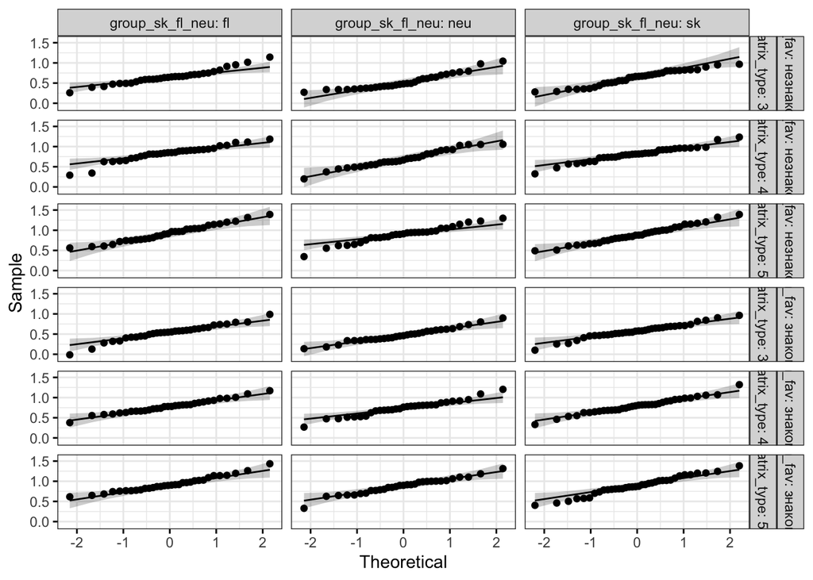

```r
ggqqplot(merged_data, "timetrans", ggtheme = theme_bw()) +
  facet_grid(stim_fav + matrix_type ~ group_sk_fl_neu, labeller = "label_both")
```

Тест на равенство дисперсий:

```r
merged_data %>%
  group_by(matrix_type, stim_fav) %>%
  levene_test(timetrans ~ group_sk_fl_neu)
```

```
## # A tibble: 6 × 6
##   matrix_type stim_fav     df1   df2 statistic     p
##   <fct>       <fct>      <int> <int>     <dbl> <dbl>
## 1 3x3         незнакомые     2    96    0.422  0.657
## 2 3x3         знакомые       2    96    0.0553 0.946
## 3 4x4         незнакомые     2    96    0.906  0.407
## 4 4x4         знакомые       2    96    0.182  0.834
## 5 5x5         незнакомые     2    96    0.297  0.743
## 6 5x5         знакомые       2    96    0.815  0.445
```

Условия для проведения диспперсионного анализа соблюдены.

```r
res.aov_bc <- anova_test(
  data = merged_data, dv = timetrans, wid = ID,
  between = group_sk_fl_neu, within = c(matrix_type, stim_fav)
)
get_anova_table(res.aov_bc)
```

```
## ANOVA Table (type III tests)
##
##                                 Effect DFn DFd       F        p p<.05   ges
## 1                      group_sk_fl_neu   2  96   1.814 1.69e-01       0.026
## 2                          matrix_type   2 192 416.855 1.38e-70     * 0.338
## 3                             stim_fav   1  96   8.956 4.00e-03     * 0.006
## 4          group_sk_fl_neu:matrix_type   4 192   3.044 1.80e-02     * 0.007
## 5             group_sk_fl_neu:stim_fav   2  96   1.851 1.63e-01       0.002
## 6                 matrix_type:stim_fav   2 192   6.277 2.00e-03     * 0.007
## 7 group_sk_fl_neu:matrix_type:stim_fav   4 192   0.977 4.21e-01       0.002
```

Полученные результаты практически идентичны обычному дисперсионному анализу, проведенному в основной части исследованя. Единственным отличием является наличие значимости у **взаимодействия факторов размера интерфейса и его дизайна**. Учитывая, что все остальные методы робустного анализа также выявили его значимым, считаем необходимым провести дальнейшее исследование.

```r
one.way_bc <- merged_data %>%
  group_by(matrix_type) %>%
  anova_test(dv = timetrans, wid = ID, between = group_sk_fl_neu) %>%
  get_anova_table() %>%
  adjust_pvalue(method = "bonferroni")
one.way_bc
```

```
## # A tibble: 3 × 9
##   matrix_type Effect            DFn   DFd     F     p `p<.05`   ges p.adj
##   <fct>       <chr>           <dbl> <dbl> <dbl> <dbl> <chr>   <dbl> <dbl>
## 1 3x3         group_sk_fl_neu     2   195 5.04  0.007 "*"     0.049 0.021
## 2 4x4         group_sk_fl_neu     2   195 4.49  0.012 "*"     0.044 0.036
## 3 5x5         group_sk_fl_neu     2   195 0.803 0.45  ""      0.008 1
```

В случае с интерфейсами малого и среднего размера имеются значимые различия между дизайнами. Уточним, какие именно.

```r
pwc_bc <- merged_data %>%
  group_by(matrix_type) %>%
  pairwise_t_test(timetrans ~ group_sk_fl_neu, p.adjust.method = "bonferroni")
pwc_bc
```

```
## # A tibble: 9 × 10
##   matrix_type .y.       group1 group2    n1    n2       p p.signif  p.adj
## * <fct>       <chr>     <chr>  <chr>  <int> <int>   <dbl> <chr>     <dbl>
## 1 3x3         timetrans fl     neu       64    62 0.00879 **       0.0264
## 2 3x3         timetrans fl     sk        64    72 0.876   ns       1
## 3 3x3         timetrans neu    sk        62    72 0.00446 **       0.0134
## 4 4x4         timetrans fl     neu       64    62 0.00905 **       0.0272
## 5 4x4         timetrans fl     sk        64    72 0.905   ns       1
## 6 4x4         timetrans neu    sk        62    72 0.0102  *        0.0306
## 7 5x5         timetrans fl     neu       64    62 0.257   ns       0.772
## 8 5x5         timetrans fl     sk        64    72 0.29    ns       0.869
## 9 5x5         timetrans neu    sk        62    72 0.908   ns       1
## # ℹ 1 more variable: p.adj.signif <chr>
```

Вариант дизайна неоморфизм отличается от других варинтов в случае с малыми и средними интерфейсами.

```r
merged_data %>%
  group_by(group_sk_fl_neu, matrix_type
           ) %>%
  get_summary_stats(time, type = "robust")
```

```
## # A tibble: 9 × 6
##   group_sk_fl_neu matrix_type variable     n median   iqr
##   <fct>           <fct>       <fct>    <dbl>  <dbl> <dbl>
## 1 fl              3x3         time        64   1.91 0.484
## 2 fl              4x4         time        64   2.50 0.692
## 3 fl              5x5         time        64   2.83 1.00
## 4 neu             3x3         time        62   1.66 0.462
## 5 neu             4x4         time        62   2.20 0.683
## 6 neu             5x5         time        62   2.81 0.806
## 7 sk              3x3         time        72   1.93 0.514
## 8 sk              4x4         time        72   2.50 0.725
## 9 sk              5x5         time        72   2.70 0.93
```

Так как мы провели степпенную трансформамцию, говорить о конкретных количественных различиях мы не можем, однако судя по робустным статистикам мы можем говорить о том, что время поиска в малых и средних неоморфических интерфейсах значимо меньше, чем в других дизайнах.